# A3: SPL Library Checkouts

### Second Trends Over Time Chart

The second chart I’m including is the “Harry Potter Books Checkout Summary Overtime Organized by Book Material Types.” The x-axis is the months in 2022 and 2023, and the y-axis is the number of checkouts. There is a total two 8 materials for the book: audiobook, physical book, ebook, music, regprint, sound disc, soundrec, and video disc. I want to include these data trends because they can help us identify people’s reading behavior on Harry Potter-related materials. This will also help us see the Harry Potter series’ popularity in different formats over time. From analyzing the data from the chart, we learned that audiobook is the most popular way for people to borrow Harry Potter-related materials, while sound rec and music are the lowest. We can also analyze the user portrait from the checkout data from the different book material types. For example, the audiobook might be the young and middle age people since they will probably have more access to technology and prefer listening to the book. At the same time, audio discs and sound discs might be scholars who are studying the topic, which requires a more detailed view of the topic.

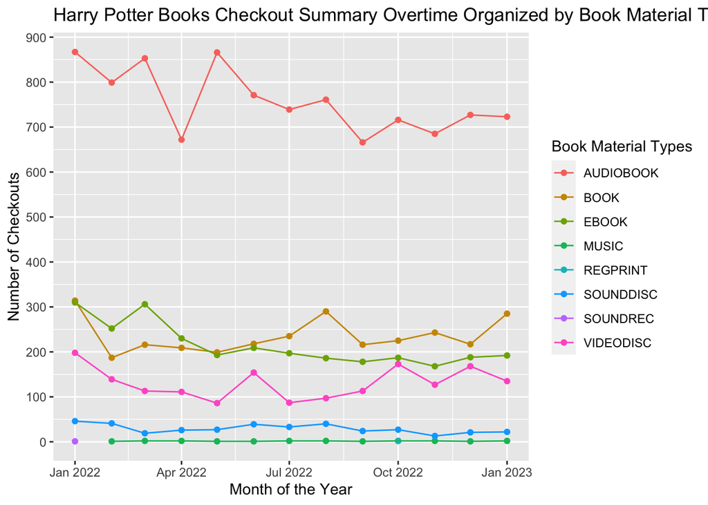

### Your Choice

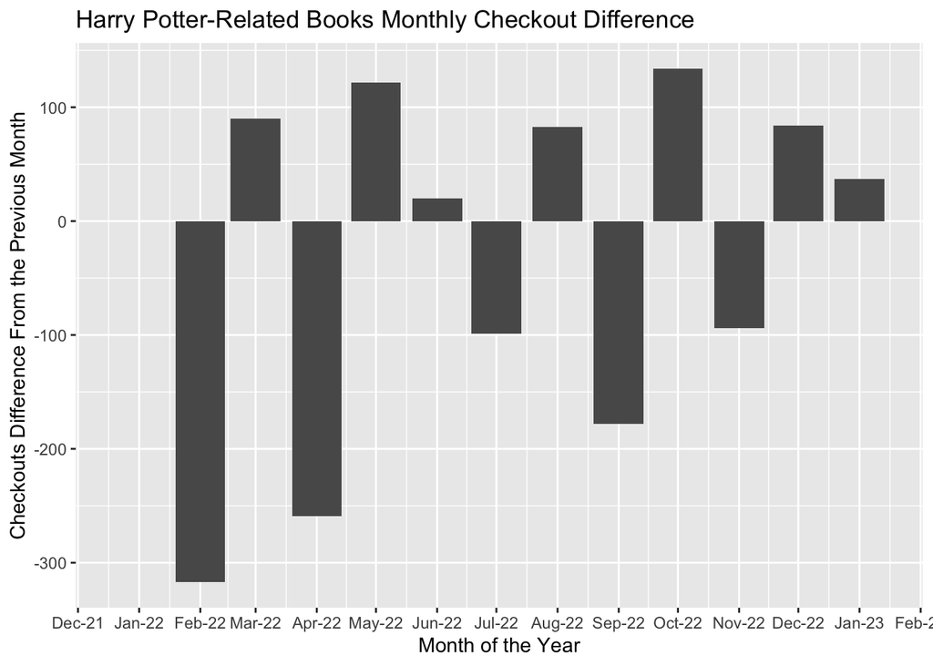